# Google Cloud's Natural Language API

- **Sentiment analysis**
- **Entity analysis**
- **Entity sentiment analysis**
- **Content classification**
- Syntactic analysis

We'll make use of Google Cloud's Natural Language API through the **googleLanguageR** package for R.

```r
# install.packages("googleLanguageR")

library(tidyverse)
library(googleLanguageR)
gl_auth("google_service_account_key.json")
```

# Sentiment analysis

**Sentiment analysis** inspects the given text and identifies the prevailing emotional opinion within the text, especially to determine a writer's attitude as positive, negative, or neutral.

Let's load a sample dataset from Datafiniti.

Source: https://data.world/datafiniti/hotel-reviews

```r
hotels_sample = read.csv("hotels_sample.csv")
head(hotels_sample)
```

A data.frame: 6 × 26

|  | X <int> | ï..id <chr> | dateAdded <chr> | dateUpdated <chr> | address <chr> | categories <chr> | primaryCategories <chr> | city <chr> | country <chr> | keys <chr> | ... | reviews.dateSeen <chr> | reviews.rating <dbl> | reviews.sourceURLs <chr> | reviews.text <chr> | reviews.title <chr> | reviews.userCity <chr> | reviews.userProvince <chr> | reviews.username <chr> | sourceURLs <chr> | websites <chr> |
| --- | --- | --- | --- | --- | --- | --- | --- | --- | --- | --- | --- | --- | --- | --- | --- | --- | --- | --- | --- | --- | --- |
| 1 | 1 | AVwcrf3WByjofQCxg_pl | 2016-05-29T02:15:56Z | 2018-01-30T05:52:32Z | 2100 S Casino Dr | Casino,Hotel,Hotels,Casino and Hotel | Accommodation & Food Services | Laughlin | US | us/nv/laughlin/2100scasinodr/-5630448 | ... | 2016-07-27T00:00:00Z | 5 | https://www.tripadvisor.com/Hotel_Review-g45964-d91988-Reviews-or120-Colorado_Belle_Hotel_Casino-Laughlin_Nevada.html%25252523REVIEWS | love to stay here, really friendly staff. Rooms are run of the mill, but comfy. One of the cheeper hotels in Laughlin. Really like the food choices it is kind of central to other places on the river. | Great trip every time | Arizona |  | rusnlu | https://foursquare.com/v/colorado-belle-hotel-and-casino/4b76f5fef964a520d56e2ee3,http://www.gayot.com/Hotels/Select-Your-City/United-States/Nevada/Laughlin/Colorado-Belle-Hotel-Casino-Laughlin-LVHOT0… | http://www.coloradobelle.com |
| 2 | 2 | AVwcrALLByjofQCxg5vg | 2016-12-13T12:13:59Z | 2018-02-07T05:24:29Z | 2260 Elkhorn Rd | Hotel,Hotels Motels,Lodging,Hotels,Motels,Hotels And Motels | Accommodation & Food Services | Lexington | US | us/ky/lexington/2260elkhornrd/-1068322787 | ... | 2016-05-10T00:00:00Z,2016-03-19T00:00:00Z | 5 | https://www.tripadvisor.com/Hotel_Review-g39588-d240387-Reviews-Motel_6_Lexington_East-Lexington_Kentucky.html,http://www.tripadvisor.com/Hotel_Review-g39588-d240387-Reviews-Motel_6_Lexington_East-Lex… | We took a few days and made a weekend trip to Lexington. We always try to stay with Motel 6 as they allow pets. This location is a little old and needs updating, but it was clean and the staff was gre… | Great People, pets welcome | Elizabethtown | KY | ElizabethHigdon1963 | https://foursquare.com/v/motel-6/4bc3f8d8dce4eee1c9d8719d,http://www.citysearch.com/profile/4314465/lexington_ky/motel_6.html,https://www.yellowpages.com/lexington-ky/mip/motel-6-3234244,http://www.lo… | https://www.motel6.com/en/motels.ky.lexington.1142.html,https://www.motel6.com/en/motels.ky.lexington.1142.html?lid=X_PMG_NaturalSearch_Local_Yext_1142&utm_source=local&utm_medium=local&utm_campaign=y… |
| 3 | 3 | AVwdPtI6IN2L1WUftxA0 | 2016-11-06T20:36:47Z | 2018-01-28T08:41:21Z | 310 Mckinley St | Hotels and motels,Hotel and motel reservations,Resorts,Hotels-Apartment,Hotels,Apartments,Hotel,Motels | Accommodation & Food Services | Hollywood | US | us/fl/hollywood/310mckinleyst/-3310337 | ... | 2016-11-05T00:00:00Z | 5 | https://www.tripadvisor.com/Hotel_Review-g34296-d642461-Reviews-or10-Neptune_Hollywood_Beach_Hotel-Hollywood_Broward_County_Florida.html%2523REVIEWS | We have a very good experience in this place. Has a excellent service and good hygiene, the staff are friendly and efficient working always in a good team Yolanda, Mirna Viktor. The magnify and comfor… | We very good experience. |  |  | Ana L | http://www.yellowbook.com/profile/neptune-hollywood-beach-hotel_1539792505.html,https://www.tripadvisor.com/Hotel_Review-g34296-d642461-Reviews-or50-Neptune_Hollywood_Beach_Hotel-Hollywood_Broward_Cou… | http://www.neptunebeachclub.com |
| 4 | 4 | AVweDjqmkufWRAb5_nSL | 2016-12-15T19:37:54Z | 2018-01-28T15:19:09Z | 1200 N Walker Ave | Hotels,Hotels and motels,Hotel,Hotel and Resort | Accommodation & Food Services | Oklahoma City | US | us/ok/oklahomacity/1200nwalkerave/-832066685 | ... | 2016-03-21T00:00:00Z | 5 | http://www.tripadvisor.com/Hotel_Review-g51560-d5244944-Reviews-Ambassador_Hotel_Oklahoma_City_Autograph_Collection-Oklahoma_City_Oklahoma.html | The property is better than stated. I travel a bit (Lifetime Marriott Platinum) and gems like this are a rare find. Not only is the property exceptionally well designed but the service adds gravitas t… | Best in class and the only place I stay in OKC... |  |  | Bradwshive | https://www.yellowpages.com/oklahoma-city-ok/mip/ambassador-hotel-oklahoma-city-autograph-collection-495615004,http://www.yellowbook.com/profile/ambassador-hotel-oklahoma-city-autograph-collection_188… | http://www.marriott.com/hotels/travel/okcak-ambassador-hotel-oklahoma-city-autograph-collection/?pid=CORPYLPandscid=45f93f1b-bd77-45c9-8dab-83b6a417f6fe,http://www.marriott.com/hotels/travel/okcak-amb… |
| 5 | 5 | AVwd9tomByjofQCxuElg | 2015-10-21T17:38:52Z | 2018-01-21T05:39:36Z | 1390 W 186th St | Hotels,Lodging,Motels,Hotels and motels,Hotel | Accommodation & Food Services | Gardena | US | us/ca/gardena/1390w186thst/779637813 | ... | 2016-03-28T00:00:00Z,2015-10-20T00:00:00Z | 5 | http://www.tripadvisor.com/Hotel_Review-g32422-d3533430-Reviews-or10-Travelodge_Inn_And_Suites_Gardena-Gardena_California.html%25252523REVIEWS,http://www.tripadvisor.com/Hotel_Review-g32422-d3533430-R… | This place is awesome. this wasn't my first time here and its even better now. The place looks brand new, futuristic like. The room was super clean and smelled great. I didn't want to leave the room. … | Stay Here Now | Laughlin | NV | nnnn702 | https://www.yellowpages.com/gardena-ca/mip/travelodge-inn-and-suites-gardena-ca-495969653,http://www.yellowbook.com/profile/travelodge-inn-and-suites-gardena-ca_1895809068.html,http://www.tripadvisor.… | http://www.travelodge.com |
| 6 | 6 | AVwdcQ_1ByjofQCxpKUm | 2016-10-14T02:03:11Z | 2018-08-27T17:00:22Z | 945 Hartle Ct | Hotels and motels,Hotel | Accommodation & Food Services | Napa | US | us/ca/napa/945hartlect/544250993 | ... | 2018-08-25T00:00:00Z | 4 | https://www.tripadvisor.com/Hotel_Review-g32766-d8872917-Reviews-or375-Hampton_Inn_and_Suites_Napa-Napa_Napa_Valley_California.html%2523REVIEWS | This is a newer place, clean and friendly service. For the business traveler this is great, one of the more economically friendly hotels in Napa. The location is good too, easy on and off and not far … | Good place to stay in Napa | Fort Collins | Colorado | JimWard99 | https://www.tripadvisor.com/Hotel_Review-g32766-d8872917-Reviews-or75-Hampton_Inn_and_Suites_Napa-Napa_Napa_Valley_California.html%2523REVIEWS,https://www.tripadvisor.com/Hotel_Review-g32766-d8872917-… | http://hamptoninn3.hilton.com/en/hotels/california/hampton-inn-and-suites-napa-APCIGHX/index.html,http://www.hamptoninnnapa.com |

```r
colnames(hotels_sample)
```

1. 'X'

2. 'ï..id'

3. 'dateAdded'

4. 'dateUpdated'

5. 'address'

6. 'categories'

7. 'primaryCategories'

8. 'city'

9. 'country'

10. 'keys'

11. 'latitude'

12. 'longitude'

13. 'name'

14. 'postalCode'

15. 'province'

16. 'reviews.date'

17. 'reviews.dateSeen'

18. 'reviews.rating'

19. 'reviews.sourceURLs'

20. 'reviews.text'

21. 'reviews.title'

22. 'reviews.userCity'

23. 'reviews.userProvince'

24. 'reviews.username'

25. 'sourceURLs'

26. 'websites'

```r
hotels_sample_clean = hotels_sample %>% select(name,city,country,province,reviews.title,reviews.rating,reviews.text)
```

Call the Natural Language API by using the function **gl_nlp** on a character vector. Use the *suppressMessages* function to prevent the console from being flooded with logs generated from each call to the API.

```r
nlp_review_text = suppressMessages(gl_nlp(hotels_sample_clean$reviews.text))
```

Let's look at the structure of the output given by the API.

```r
class(nlp_review_text)
summary(nlp_review_text)
```

'list'

```
                  Length Class  Mode
sentences         1000   -none- list
tokens            1000   -none- list
entities          1000   -none- list
language          1000   -none- character
text              1000   -none- character
documentSentiment    2   tbl_df list
classifyText      1000   -none- list
```

```r
head(nlp_review_text$documentSentiment,10)
```

A tibble: 10 × 2

| magnitude <dbl> | score <dbl> |
| --- | --- |
| 2.1 | 0.5 |
| 2.3 | 0.5 |
| 3.6 | 0.7 |
| 3.3 | 0.5 |
| 6.6 | 0.5 |
| 7.3 | 0.9 |
| NA | NA |
| 6.7 | 0.5 |
| 3.5 | 0.5 |
| 2.4 | 0.3 |

```r
nlp_review_text$sentences[[1]]
```

A data.frame: 4 × 4

| content <chr> | beginOffset <int> | magnitude <dbl> | score <dbl> |
| --- | --- | --- | --- |
| love to stay here, really friendly staff. | 0 | 0.9 | 0.9 |
| Rooms are run of the mill, but comfy. | 42 | 0.1 | 0.1 |
| One of the cheeper hotels in Laughlin. | 80 | 0.0 | 0.0 |
| Really like the food choices it is kind of central to other places on the river. | 119 | 0.9 | 0.9 |

```r
# Get rid of NAs
sample_w_senti = na.omit(cbind(hotels_sample_clean,nlp_review_text$documentSentiment))
```

```r
head(sample_w_senti)
```

A data.frame: 6 × 9

|  | name <chr> | city <chr> | country <chr> | province <chr> | reviews.title <chr> | reviews.rating <dbl> | reviews.text <chr> | magnitude <dbl> | score <dbl> |
| --- | --- | --- | --- | --- | --- | --- | --- | --- | --- |
| 1 | Colorado Belle Hotel And Casino | Laughlin | US | NV | Great trip every time | 5 | love to stay here, really friendly staff. Rooms are run of the mill, but comfy. One of the cheeper hotels in Laughlin. Really like the food choices it is kind of central to other places on the river. | 2.1 | 0.5 |
| 2 | Motel 6 | Lexington | US | KY | Great People, pets welcome | 5 | We took a few days and made a weekend trip to Lexington. We always try to stay with Motel 6 as they allow pets. This location is a little old and needs updating, but it was clean and the staff was gre… | 2.3 | 0.5 |
| 3 | Neptune Hollywood Beach Hotel | Hollywood | US | FL | We very good experience. | 5 | We have a very good experience in this place. Has a excellent service and good hygiene, the staff are friendly and efficient working always in a good team Yolanda, Mirna Viktor. The magnify and comfor… | 3.6 | 0.7 |
| 4 | Ambassador Hotel Oklahoma City, Autograph Collection | Oklahoma City | US | OK | Best in class and the only place I stay in OKC... | 5 | The property is better than stated. I travel a bit (Lifetime Marriott Platinum) and gems like this are a rare find. Not only is the property exceptionally well designed but the service adds gravitas t… | 3.3 | 0.5 |
| 5 | Travelodge Inn And Suites Gardena CA | Gardena | US | CA | Stay Here Now | 5 | This place is awesome. this wasn't my first time here and its even better now. The place looks brand new, futuristic like. The room was super clean and smelled great. I didn't want to leave the room. … | 6.6 | 0.5 |
| 6 | Hampton Inn and Suites Napa | Napa | US | CA | Good place to stay in Napa | 4 | This is a newer place, clean and friendly service. For the business traveler this is great, one of the more economically friendly hotels in Napa. The location is good too, easy on and off and not far … | 7.3 | 0.9 |

### plot of rating against score

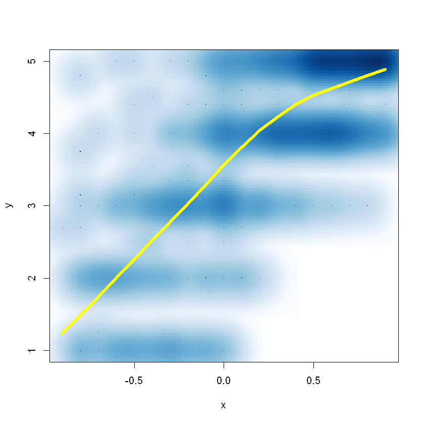

```r
x = sample_w_senti$score
y = sample_w_senti$reviews.rating
smoothScatter(x,y)
lines(lowess(x, y), col = "yellow", lwd=5)
```

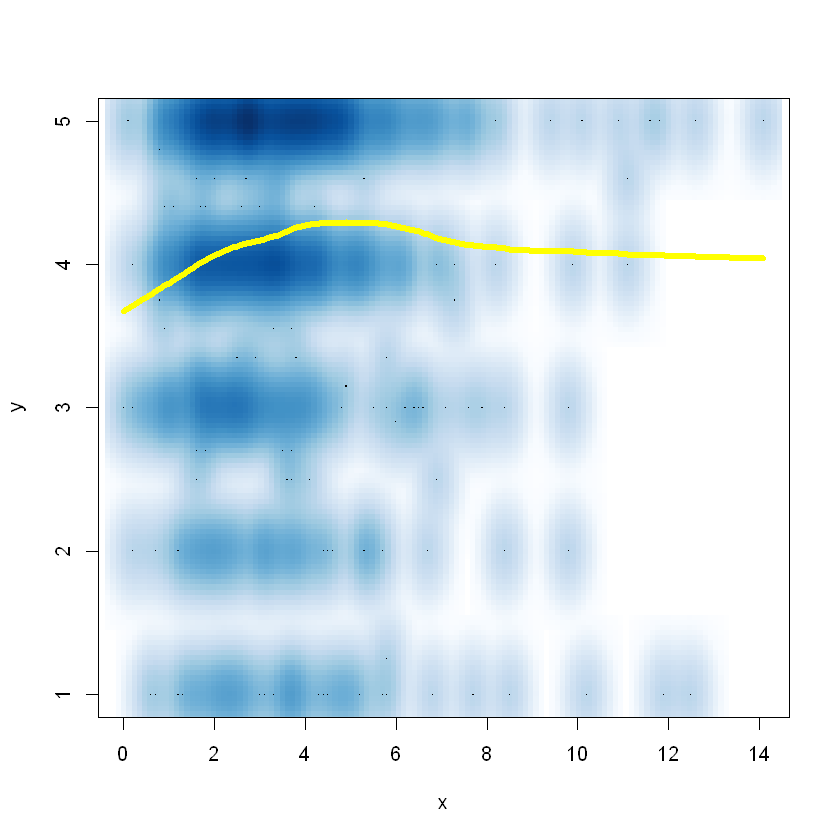

```r
x = sample_w_senti$magnitude
y = sample_w_senti$reviews.rating
smoothScatter(x,y)
lines(lowess(x, y), col = "yellow", lwd=5)
```

### plot of rating against score * magnitude

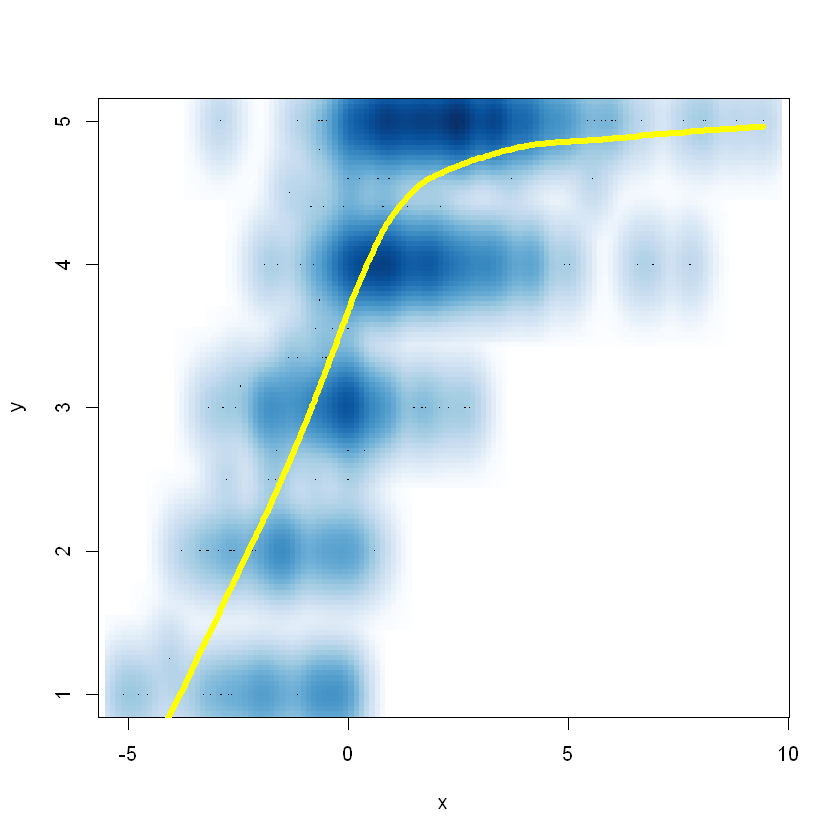

```r
x = sample_w_senti$score * sample_w_senti$magnitude
y = sample_w_senti$reviews.rating
smoothScatter(x,y)
lines(lowess(x, y), col = "yellow", lwd=5)
```

Let's try to see the sentiment analysis for the longest review.

```r
which(nchar(hotels_sample_clean$reviews.text)==max(nchar(hotels_sample_clean$reviews.text)))
```

746

```r
print(hotels_sample_clean$reviews.text[746])
```

```
[1] "On my most recent work trip to NYC, I chose to stay at the St Regis vs my usual (The Peninsula). Never again will I go back. After a long day of client meetings, I decided to grab a light dinner and drink at the hotel lobby bar (King Cole Bar). I travel quite a bit for work and my one rule of t…
```

```r
nlp_review_text$documentSentiment[746,]
```

A tibble: 1 × 2

| magnitude <dbl> | score <dbl> |
| --- | --- |
| 12.5 | -0.2 |

```r
# Removed the hotel's reply to the review
fixed_longest_review = "On my most recent work trip to NYC, I chose to stay at the St Regis vs my usual (The Peninsula). Never again will I go back. After a long day of client meetings, I decided to grab a light dinner and drink at the hotel lobby bar (King Cole Bar). I travel quite a bit for work and my one rule of thumb is to avoid being holed up in a room with room service. I headed straight to the bar after getting back to the hotel and intentionally grabbed a small table in the far corner as I knew I\'d need to get some work in to clear all my emails from the day. Literally within 15 seconds of powering on my laptop, one of the servers bolted over to me and asked if I was aware that they had a No Laptop Policy after 4pm. Seriously I had to ask myself, was I really staying at a 5-star business property I politely pushed back and said I was a guest at the hotel and had to get some work done and would be out of there quickly after my meal. He looked annoyed but then retreated.Fast forward 15-20 minutes...my food and wine arrives and I\'m not even halfway through. That\'s when the FB manager then approaches me. He actually had the audacity to ask how much longer will I be on my laptop as I am being disruptive. Again, to set the context, I am sitting in the far corner next to a pillar and had my laptop screen dimmed to the lowest setting. I am not engaging with anyone yet I\'m being disruptive One would think an FB manager would have some business and common sense and decency to recognize that you don\'t go and ask a paying guest at the hotel to get up in the middle of a meal because they are working on their laptop. When I told him I didn\'t understand their policy and why he was enforcing it, he said I was not fitting in to the bar scene. Unbelievable. He then tells me he\'d be happy to have my food and wine moved outside the bar where I could freely work. I am at this point just dumbfounded. It was like being asked to move to the back of the bus or get off the bus for that matter. Most humiliating and distasteful experience ever and never ever would I have imagined it would be on a work trip at what\'s supposed to be an upstanding hotel. And just to be clear, on the many occasions I\'ve had to power up my laptop at the bar at The Peninsula to get some work done, not once did anyone ask me to turn off my laptop or leave. Crystal clear for me now..."

fixed_longest_review_nlp = gl_nlp(fixed_longest_review)
```

```
2020-11-11 23:19:48 -- annotateText: 2359 characters
```

```r
fixed_longest_review_nlp$documentSentiment
```

A tibble: 1 × 2

| magnitude <dbl> | score <dbl> |
| --- | --- |
| 9.9 | -0.4 |

# Entity analysis

**Entity analysis** inspects the given text for known entities (proper nouns such as public figures, landmarks, etc., and common nouns such as restaurant, stadium, etc.) and returns information about those entities.

```r
wiki_txt = "On June 15, 2006, Gates announced that he would transition out of his role at Microsoft to dedicate more time to philanthropy. He divided his responsibilities between two successors when he placed Ray Ozzie in charge of management and Craig Mundie in charge of long-term product strategy."
print(wiki_txt)
```

```
[1] "On June 15, 2006, Gates announced that he would transition out of his role at Microsoft to dedicate more time to philanthropy. He divided his responsibilities between two successors when he placed Ray Ozzie in charge of management and Craig Mundie in charge of long-term product strategy."
```

```r
wiki_nlp = gl_nlp(wiki_txt)
```

```
2020-11-12 07:47:18 -- annotateText: 288 characters
```

```r
colnames(wiki_nlp$entities[[1]])
```

1. 'name'

2. 'type'

3. 'salience'

4. 'wikipedia_url'

5. 'mid'

6. 'year'

7. 'month'

8. 'day'

9. 'value'

10. 'magnitude'

11. 'score'

12. 'beginOffset'

13. 'mention_type'

The **salience** score of an entity reflects its relevance to the entire document text. Scores closer to 0 are less salient, while scores closer to 1.0 are highly salient.

```r
arrange(wiki_nlp$entities[[1]],desc(salience)) %>% select(name,type,salience,mention_type,wikipedia_url)
```

A tibble: 18 × 5

| name <chr> | type <chr> | salience <dbl> | mention_type <chr> | wikipedia_url <chr> |
| --- | --- | --- | --- | --- |
| Gates | PERSON | 0.725987100 | PROPER | NA |
| philanthropy | OTHER | 0.056029294 | COMMON | NA |
| role | OTHER | 0.055361744 | COMMON | NA |
| Microsoft | ORGANIZATION | 0.033065367 | PROPER | https://en.wikipedia.org/wiki/Microsoft |
| responsibilities | OTHER | 0.025019607 | COMMON | NA |
| successors | PERSON | 0.025019607 | COMMON | NA |
| charge | OTHER | 0.021497300 | COMMON | NA |
| charge | OTHER | 0.021497300 | COMMON | NA |
| management | OTHER | 0.018903317 | COMMON | NA |
| product strategy | OTHER | 0.013261516 | COMMON | NA |
| Craig Mundie | PERSON | 0.011208309 | PROPER | https://en.wikipedia.org/wiki/Craig_Mundie |
| charge | OTHER | 0.009473343 | COMMON | NA |
| charge | OTHER | 0.009473343 | COMMON | NA |
| Ray Ozzie | PERSON | 0.005173501 | PROPER | https://en.wikipedia.org/wiki/Ray_Ozzie |
| 15 | NUMBER | 0.000000000 | TYPE_UNKNOWN | NA |
| 2006 | NUMBER | 0.000000000 | TYPE_UNKNOWN | NA |
| June 15, 2006 | DATE | 0.000000000 | TYPE_UNKNOWN | NA |
| two | NUMBER | 0.000000000 | TYPE_UNKNOWN | NA |

# Entity sentiment analysis

**Entity sentiment analysis** inspects the given text for known entities (proper nouns and common nouns), returns information about those entities, and identifies the prevailing emotional opinion of the entity within the text, especially to determine a writer's attitude toward the entity as positive, negative, or neutral.

```r
sgv_review = "Career development is a certainty since trainings/seminars are usually provided to keep up to date with GAAP and new standards. Location is accessible to commuters and there are a lot of choices to buy food from. The amenities: Cafeteria has great and cheap food, free gym usage but you have to schedule a time for use, equipment provided are abreast with new technologies. Reimbursements for transportation and food especially on out of town fieldworks. You sometimes get to travel to out of town places for fieldwork. No social life at all. Your life will revolve around work and you almost always have to work on weekends to meet unrealistic deadlines and heavy workload. Low pay and almost almost no overtime pay: Salary is not competitive for a professional. Overtime pay is almost always not paid due to budget restrictions in the engagement. Heavy workload: The firm always accepts new clients despite scarcity of people which ends up affecting work allocation of the work of 2 or 3 persons to one personnel only."
sgv_review_nlp = gl_nlp(sgv_review)
```

```
2020-11-12 00:00:14 -- annotateText: 1020 characters
```

How many entities were recognized? (Note that there could be duplicates.)

```r
nrow(sgv_review_nlp$entities[[1]])
```

59

```r
random_ents = sample.int(nrow(sgv_review_nlp$entities[[1]]),10)
```

```r
sgv_review_nlp$entities[[1]][random_ents,c('name','type','salience','mention_type','magnitude','score')]
```

A tibble: 10 × 6

| name <chr> | type <chr> | salience <dbl> | mention_type <chr> | magnitude <dbl> | score <dbl> |
| --- | --- | --- | --- | --- | --- |
| food | OTHER | 0.012329616 | COMMON | 0.8 | 0.8 |
| work | OTHER | 0.012900647 | COMMON | 0.1 | -0.1 |
| gym usage | OTHER | 0.009885157 | COMMON | 0.5 | 0.5 |
| equipment | CONSUMER_GOOD | 0.009645567 | COMMON | 0.6 | 0.6 |
| Career development | OTHER | 0.362840470 | COMMON | 1.0 | 0.5 |
| workload | OTHER | 0.004272769 | COMMON | 0.8 | -0.8 |
| food | OTHER | 0.020214700 | COMMON | 0.1 | 0.1 |
| Salary | OTHER | 0.003610378 | COMMON | 0.8 | -0.8 |
| food | OTHER | 0.012329616 | COMMON | 0.8 | 0.8 |
| clients | OTHER | 0.006822741 | COMMON | 0.0 | 0.0 |

# Content classification

**Content classification** analyzes text content and returns a content category for the content.

#### 1. PS5 Order Guide For Launch: Where To Buy A PS5 On November 12 (GameSpot)

We're now just one day away from the PlayStation 5 launch on November 12, which will mark the beginning of a new generation of gaming for PlayStation fans. The PS5 and PS5 Digital, which retail for $500 and $400, respectively, first went up for preorder on September 16 and quickly sold out, and finding the systems in stock has been near-impossible in the months since.

#### 2. Brownouts hit NCR amid Ulysses rains, winds; linemen on standby, Meralco says (PhilStar)

Power outages hit different parts of Metro Manila on Thursday amid heavy rains and howling winds brought about by Typhoon Ulysses.

State weather bureau raised a red rainfall warning over Metro Manila and nearby Quezon, Bulacan, Laguna, and Rizal early Thursday morning as Ulysses made its way across Luzon.

#### 3. Stocks soar on news of COVID-19 vaccine breakthrough (GMA News)

Stock investors largely ignored the wider-than-expected economic decline in the third quarter and instead turned upbeat on news of a major breakthrough in the development of a COVID-19 vaccine.

The 30-company Philippine Stock Exchange index or PSEi finished as the best performer in Asia yesterday, gaining 349.63 points or 5.22 percent to vault past the 7,000 mark for the first time since February.

US-based pharmaceutical giant Pfizer said on Monday its experimental vaccine was more than 90 percent effective in preventing COVID-19 based on initial data from a large study, a major victory in the fight against the pandemic, according to a Reuters report.

```r
content_txt = c("We're now just one day away from the PlayStation 5 launch on November 12, which will mark the beginning of a new generation of gaming for PlayStation fans. The PS5 and PS5 Digital, which retail for $500 and $400, respectively, first went up for preorder on September 16 and quickly sold out, and finding the systems in stock has been near-impossible in the months since.",
                "Power outages hit different parts of Metro Manila on Thursday amid heavy rains and howling winds brought about by Typhoon Ulysses.

State weather bureau raised a red rainfall warning over Metro Manila and nearby Quezon, Bulacan, Laguna, and Rizal early Thursday morning as Ulysses made its way across Luzon.",
                "Stock investors largely ignored the wider-than-expected economic decline in the third quarter and instead turned upbeat on news of a major breakthrough in the development of a COVID-19 vaccine.

The 30-company Philippine Stock Exchange index or PSEi finished as the best performer in Asia yesterday, gaining 349.63 points or 5.22 percent to vault past the 7,000 mark for the first time since February.

US-based pharmaceutical giant Pfizer said on Monday its experimental vaccine was more than 90 percent effective in preventing COVID-19 based on initial data from a large study, a major victory in the fight against the pandemic, according to a Reuters report.")
```

```r
content_nlp = gl_nlp(content_txt)
```

```
2020-11-12 08:14:01 -- annotateText: 370 characters

Error in curl::curl_fetch_memory(url, handle = handle): Timeout was reached: [language.googleapis.com] Send failure: Connection was reset
Request failed [ERROR]. Retrying in 1 seconds...

2020-11-12 08:14:15 -- annotateText: 307 characters

2020-11-12 08:14:16 -- annotateText: 661 characters
```

```r
content_nlp$classifyText
```

1. A tibble: 2 × 2

   | name <chr> | confidence <dbl> |
   | --- | --- |
   | /Games/Computer & Video Games | 0.97 |
   | /Computers & Electronics/Consumer Electronics/Game Systems & Consoles | 0.94 |

2. A tibble: 1 × 2

   | name <chr> | confidence <dbl> |
   | --- | --- |
   | /News/Weather | 0.66 |

3. A tibble: 3 × 2

   | name <chr> | confidence <dbl> |
   | --- | --- |
   | /Finance/Investing | 0.84 |
   | /Business & Industrial | 0.69 |
   | /News | 0.54 |